# Enquête pour l’Etablissement Français du Sang

Valentin Henriot / Marie Rodriguez / Jules Bayer / Renaud Teglia / Carla Pardon / Jimmy Moreau / Laurianne Guinet

22/03/2020

Dans le cadre de notre cours de Marketing Research, nous avons mené une enquête pour l’établissement français du sang. Cette enquête a été menée auprès d’un échantillon de 3312 individus. Ces individus devaient répondre à 66 questions, certaines sous forme d’une échelle de valeur (ex: le degré d’utilité ressenti au fait de donner son sang), d’autres sous forme de facteur (ex: le type de sang). Pour réaliser cette étude, nous avons utiliser le logiciel open-source Rstudio (sur le serveur de SKEMA Global Lab in AI), qui est un outil de DataScience, notamment utilisé dans l’exploitation statistique des données de masse. Dans un premier temps, nous avons défini l’échantillon sur lequel nous souhaitions nous concentrer, ensuite, nous avons transformé certaines valeurs numériques du fichier de base en valeurs texte dans un souci de compréhension de la data.

L’étude s’articule sur 3 axes, le premier concerne le profil des répondants (sexe, âge, lieu de naissance, etc). Le second vise à démontrer des liens de corrélation entre différentes variables (ex : y a t’il un lien entre le fait de trouver utile de donner son sang et réellement le donner ?) Enfin, le dernier axe est la combinaison des deux premiers, c’est à dire, le lien entre le profil des répondants et les réponses données au questionnaire.

# **Profil des répondants**

Nous avons choisi de garder un échantillon de 2392 individus, en effet, nous trouvions pertinent de garder uniquement les personnes ayant répondu à au moins 50% des questions du questionnaire. Toutefois, pour pouvoir analyser ces données de la façon la plus précise possible, nous avons fait le choix de réduire encore cette population de 2392 individus suivant les analyses que nous effectuons. Par exemple, dans l’analyse visant à démontrer s’il existe un lien entre le lieu de naissance et le groupe sanguin, nous excluerons tous les individus ayant indiqué qu’ils ne connaissaient pas leur groupe sanguin.

## Lieu de naissance

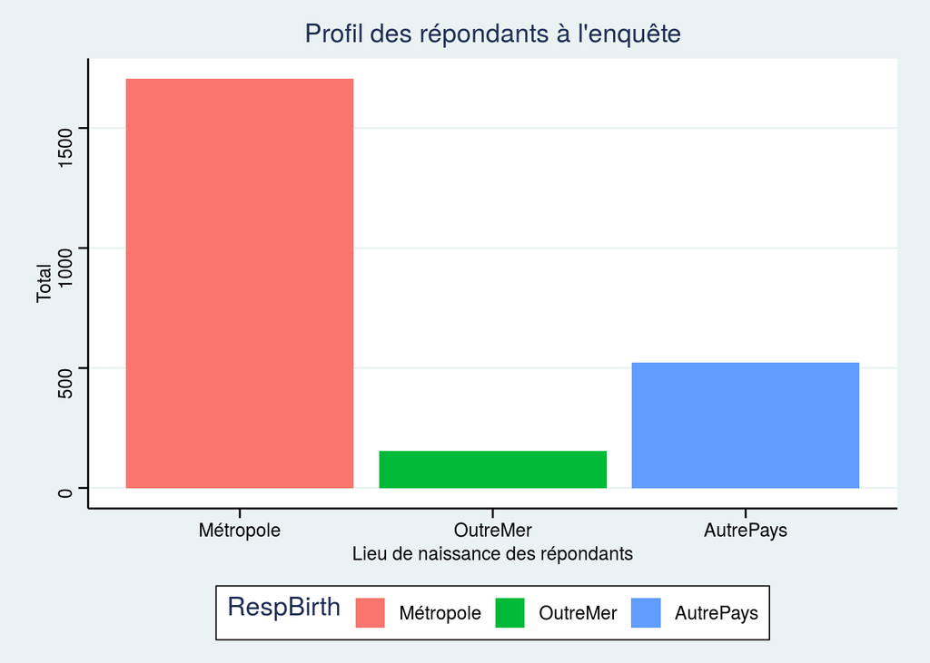

Les individus nés en métropole représentent 71% de l’échantillon des répondants retenus (ceux ayant répondus à au moins 50% des questions), ceux d’OutreMer représentent 6%, ceux étant nés dans un autre pays représentent eux 22% de l’échantillon. Enfin, ceux n’ayant pas indiqué leur lieu de naissance représentent 1% de l’échantillon.

## Sexe

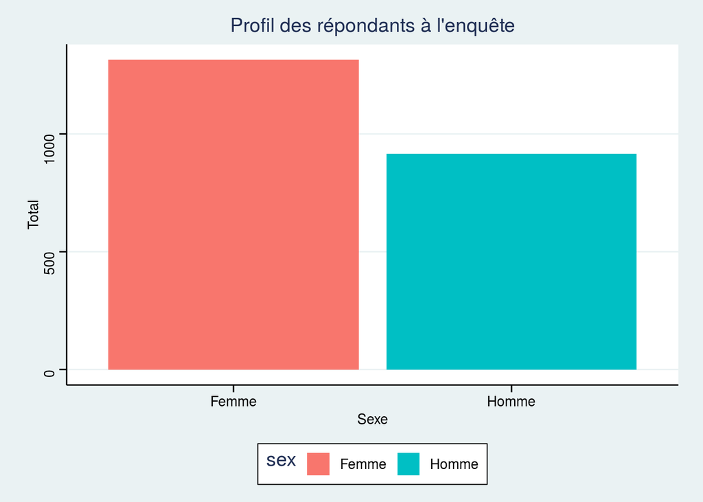

Les femmes représentent la part la plus importante de cet échantillon, elles représentent 55% de l’échantillon, les hommes représentent 38% et enfin, ceux n’ayant pas indiqué leur sexe représentent 7%.

## Groupe sanguin

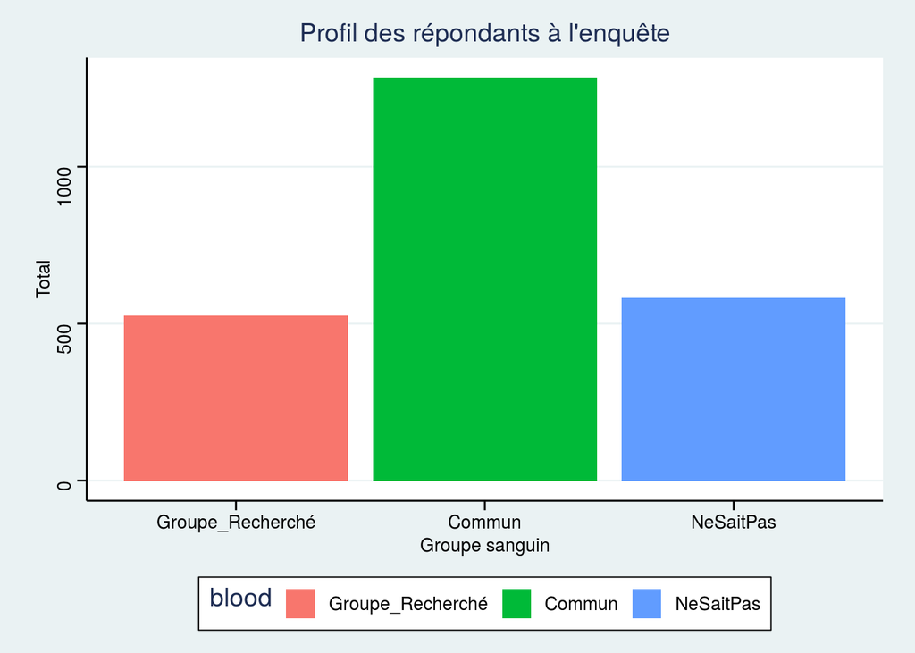

Les individus avec un groupe sanguin commun représentent 53% de l’échantillon, ceux avec un groupe sanguin recherché représentent 22% et enfin, ceux ne connaissant pas leur groupe sanguin représentent les 25% restants.

### Lien entre groupe sanguin et lieu de naissance ?

Dans cette première analyse, nous allons essayer de voir s’il existe un lien ou non entre le groupe sanguin de l’individu et le lieu de naissance qu’il a indiqué. Pour cela, nous réalisons un test de khi-deux, permettant de démontrer la dépendance entre deux variables.

|  | Groupe_Recherché | Commun |
| --- | --- | --- |
| Métropole | 385 | 925 |
| OutreMer | 28 | 85 |
| AutrePays | 108 | 268 |

La première variable est le lieu de naissance, nous avons donc exclu les personnes n’ayant pas répondu à cette question. La deuxième variable est le type de sang, là encore, nous avons exclu ceux ayant répondu “Ne sait pas” ou n’ayant tout simplement pas répondu. Le tableau de contingence ci-dessus indique donc les différents effectifs en fonction de ces deux différentes variables.

|  | Groupe_Recherché | Commun |
| --- | --- | --- |
| Métropole | 379.3830 | 930.6170 |
| OutreMer | 32.7254 | 80.2746 |
| AutrePays | 108.8916 | 267.1084 |

Le tableau ci dessus indique les effectifs que nous aurions normalement dû avoir si le tableau était rempli de manière proportionnelle. Nous pouvons constater que la différence avec le premier tableau n’est pas significative, les valeurs sont proches.

```
##
##  Pearson's Chi-squared test
##
## data:  EFSkhideux_test
## X-squared = 1.0878, df = 2, p-value = 0.5805
```

Le test de Khi-deux nous indique que nous avons seulement deux degrés de liberté et la p-value du test indique un résultat de 0,5805. Pour prouver un lien de dépendance entre deux variables, il faut que la p-value soit inférieure à 0,05, ici donc, ce test nous démontre qu’il n’y a aucun lien de dépendance entre le lieu de naissance et le type de sang. Attention, il faut toutefois nuancer ce constat, en effet, les répondants étant nés à l’étranger ou en outre-mer sont minoritaires dans cette enquête. Ainsi, à plus grande échelle, les résultats auraient pu différer.

Dans la deuxième partie de cette analyse, nous analyserons si le lieu de naissance des parents influe sur le groupe sanguin ou non.

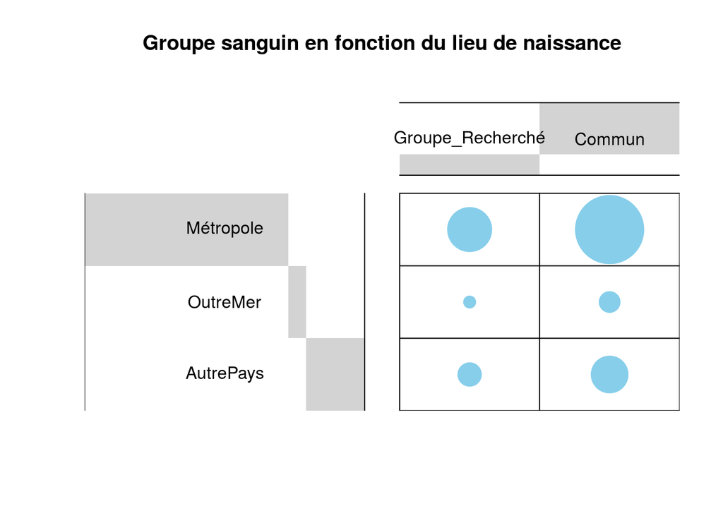

Le graphique ci dessus indique le poids de chaque variable, matérialisé par la barre grise (on voit donc que pour le lieu de naissance, c’est la métropole qui représente la part la plus importante pour la variable lieu de naissance). Les ronds représentent le poids de chaque valeur en fonction de chaque variable.

| blood | Métropole | OutreMer | AutrePays | <NA> |
| --- | --- | --- | --- | --- |
| Groupe_Recherché | 385 | 28 | 108 | 4 |
| Commun | 925 | 85 | 268 | 6 |
| NeSaitPas | 395 | 40 | 147 | 1 |

Nous avons volontairement exclu les personnes ne connaissant pas leur groupe sanguin de l’analyse précédente. Toutefois, il est intéressant de noter que, les personnes nées en métropole sont 23% à ignorer leur groupe sanguin, 26% pour ceux étant nés en Outre-Mer et enfin 28% pour ceux étant nés dans un autre pays. Enfin, seulement 11 individus n’ont pas indiqué de lieu de naissance.

# **Analyse des corrélations entre variables**

Pour pouvoir réaliser l’analyse de corrélation, on garde uniquement les individus ayant répondu à l’ensemble des questions (hormis celles qui sont non-chiffrées). L’analyse de corrélation se fait donc sur une population de 956 individus.

## Relation entre lieu de naissance des parents et groupe sanguin

Pour faire suite à l’analyse en première partie concernant le lieu de naissance de l’individu interrogé et son groupe sanguin, nous estimons qu’il est pertinent d’étudier la corrélation qu’il pourrait y avoir entre le groupe sanguin et le lieu de naissance des parents. En effet, la transmission du groupe sanguin a une part héréditaire.

| MotherBirth | FatherBirth | count |
| --- | --- | --- |
| Métropole | Métropole | 336 |
| Métropole | OutreMer | 10 |
| Métropole | AutrePays | 81 |
| OutreMer | Métropole | 12 |
| OutreMer | OutreMer | 52 |
| OutreMer | AutrePays | 4 |
| AutrePays | Métropole | 50 |
| AutrePays | OutreMer | 4 |
| AutrePays | AutrePays | 407 |

Ce premier tableau montre la répartition de l’effectif en fonction du lieu de naissance des parents. Comme nous pouvons constater, parmis les personnes interrogées, ce sont les individus donc les deux parents sont nés dans un autre pays qui représentent la part la plus importante (407 individus). Suivi par les individus dont les deux parents sont nés en métropole (336 individus). Ce tableau permettra de servir de base avec le tableau suivant. Nous calculerons un ratio entre le lieu de naissance des parents et les effectifs ayant un groupe sanguin recherché.

| blood | MotherBirth | FatherBirth | count |
| --- | --- | --- | --- |
| Groupe_Recherché | Métropole | Métropole | 77 |
| Groupe_Recherché | Métropole | OutreMer | 3 |
| Groupe_Recherché | Métropole | AutrePays | 20 |
| Groupe_Recherché | OutreMer | Métropole | 2 |
| Groupe_Recherché | OutreMer | OutreMer | 5 |
| Groupe_Recherché | OutreMer | AutrePays | 2 |
| Groupe_Recherché | AutrePays | Métropole | 11 |
| Groupe_Recherché | AutrePays | OutreMer | 1 |
| Groupe_Recherché | AutrePays | AutrePays | 97 |

Ce tableau représente les effectifs ayant un groupe sanguin recherché en fonction du lieu de naissance des parents. Pour la base de notre calcul, nous choisissons uniquement les effectifs représentant une valeur supérieure à 20 afin de ne pas biaiser le résultat (ex : ceux ayant une mère née en outre mer et un père né dans un autre pays représentent 4 personnes sur l’échantillon total, sur ces 4 individus, 2 déclarent avoir un groupe sanguin recherché. L’effectif est donc trop bas pour en tirer une conclusion fiable).

Ratios :

- Les 2 parents nés en métropole : 77/336*100 = 22%
- Les 2 parents nés en Outremer : 9,6%
- Les 2 parents nés dans un autre pays : 24%
- Mère née en métropole / Père né dans un autre pays : 24,6%
- Mère née dans un autre pays / Père né en métropole : 22%

La conclusion que nous pouvons tirer de cette analyse est que les personnes dont les deux parents sont nés en Outremer ont moins de 10% de “chance” d’avoir un groupe sanguin recherché. Les individus dont les deux parents (ou au moins un des deux) sont nés dans un autre pays ont entre 22% et 24,6% de chance d’avoir un groupe sanguin recherché, ce résultat est un peu plus élevé que pour les individus dont les deux parents sont nés en métropole (22%).

### Analyse du groupe sanguin en fonction du pays de naissance des parents

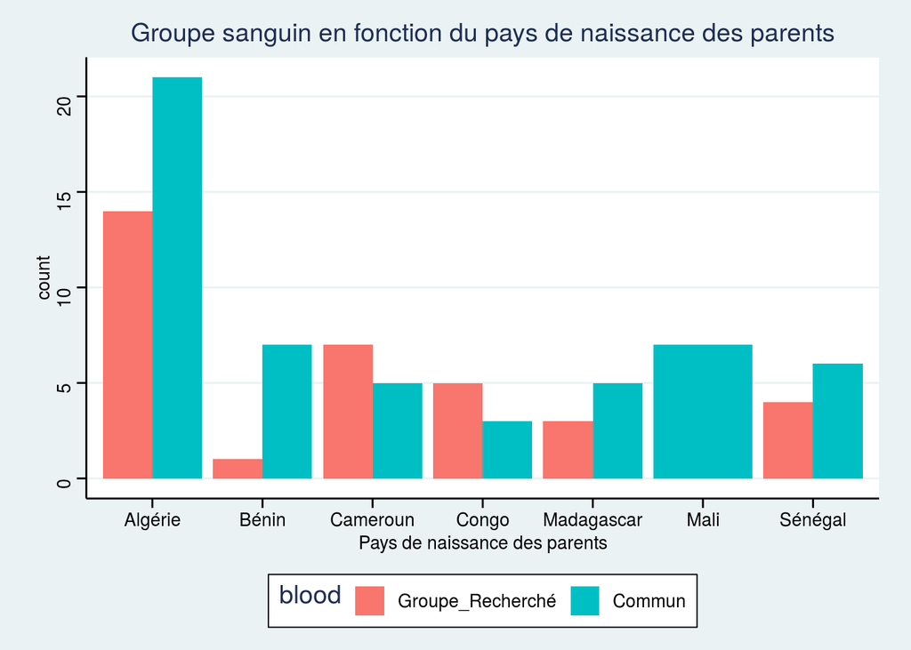

Ce graphique vise à démontrer le type du groupe sanguin en fonction du pays de naissance des parents. Dans une précédente analyse, nous avons cherché à savoir si le lieu de naissance pouvait avoir une influence ou non sur le type de sang, cette dernière s’était montrée non concluante. Cette analyse nous apprend que les individus dont les deux parents sont nés au Cameroun ou au Congo, ont plus de chance d’avoir un groupe sanguin recherché qu’un groupe sanguin commun, respectivement 58% et 62,5%. Le Sénégal et Madagascar affichent des proportions intéressantes sur le ratio groupe sanguin recherché / commun, respectivement 40% et 37,5%. Sur notre échantillon, les individus dont les deux parents sont nés au Mali ont uniquement un groupe sanguin commun. Il faut toutefois être prudent vis-à-vis de ces chiffres, en effet, ces derniers se basent sur des très petits effectifs, ils servent néanmoins à montrer une tendance.

## Ressenti pour le don du sang

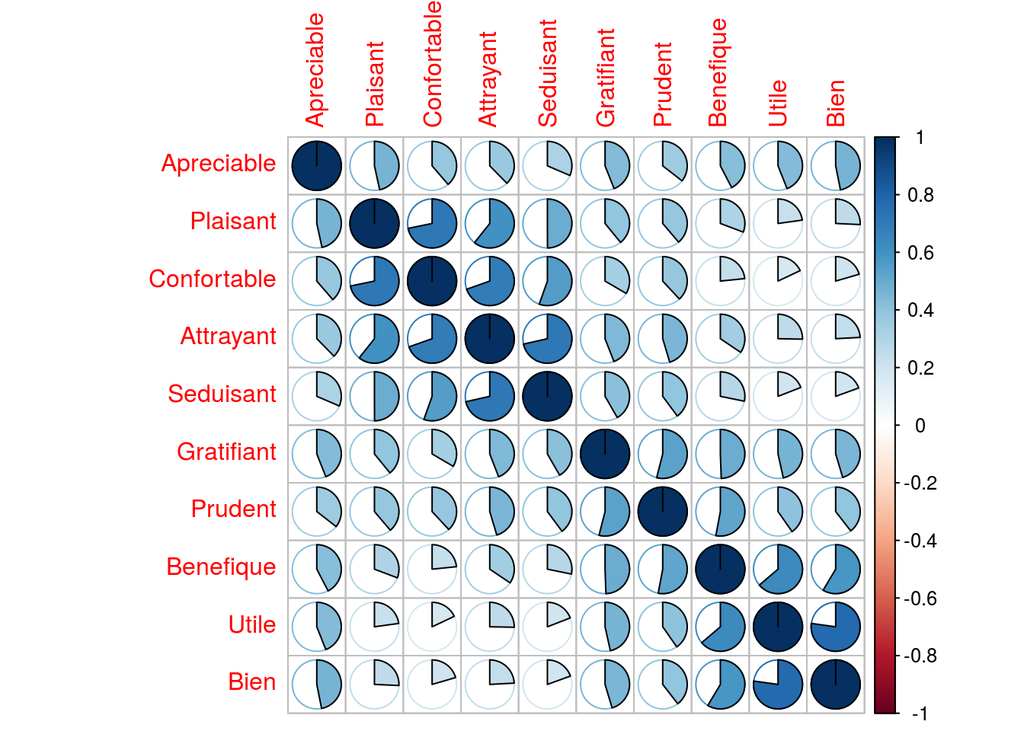

Notre première analyse porte sur l’analyse de corrélation concernant les réponses aux questions liés aux intitulés des variables ci dessus. Nous pouvons donc constater qu’il existe quelques corrélations entre ces différentes variables. Notamment les suivantes :

- Confortable / Plaisant
- Confortable / Attrayant
- Attrayant / Séduisant
- Bénéfique / Utile
- Utile / Bien

Concrètement, cela veut dire que les personnes ayant répondu une valeur élevée pour confortable (par exemple), auront tendance également à répondre une valeur élevée pour plaisant et attrayant. Ces corrélations peuvent se révéler utiles notamment en vue d’établir des actions de communication auprès du grand public.

## Relation entre lieu de naissance et intention de donner son sang

| RespBirth | intention | intention2 | intention3 | count |
| --- | --- | --- | --- | --- |
| Métropole | 1 | 1 | 1 | 41 |
| Métropole | 7 | 7 | 7 | 309 |
| OutreMer | 1 | 1 | 1 | 3 |
| OutreMer | 7 | 7 | 7 | 24 |
| AutrePays | 1 | 1 | 1 | 11 |
| AutrePays | 7 | 7 | 7 | 107 |

Le tableau ci-dessus représente les résultats donnés concernant les intentions en fonction du lieu de naissance. Ainsi, il va être intéressant d’étudier les valeurs extrèmes en fonction du lieu de naissance. C’est à dire ceux ayant donné le chiffre 1 (plus basse intention) sur les 3 variables et ceux ayant donné la note maximum. Ensuite, nous calculons la moyenne par rapport à l’effectif total pour le lieu de naissance donné. Cela permettra de voir s’il existe un lien entre le lieu de naissance et les intentions des individus.

- Pour la métropole en plus basse valeur : 41/662*100 soit 6%
- Pour la métropole en plus haute valeur : 46,6%
- Pour l’Outremer en plus basse valeur : 5%
- Pour l’Outremer en plus haute valeur : 41%
- Pour les autres pays en plus basse valeur : 4,6%
- Pour les autres pays en plus haute valeur : 45%

Cette analyse démontre donc qu’il n’y a pas de lien particulier entre l’intention de donner son sang et le lieu de naissance, en effet, le résultat de l’analyse démontre que les résultats sont très similaires peu importe le lieu de naissance.

## Relation entre religion, groupe sanguin et intention de don

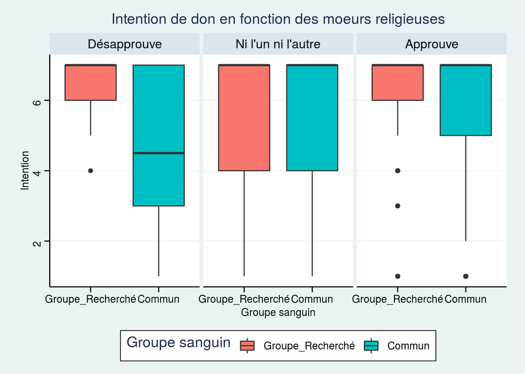

## Fréquence de don du sang en fonction du lieu de naissance et groupe sanguin

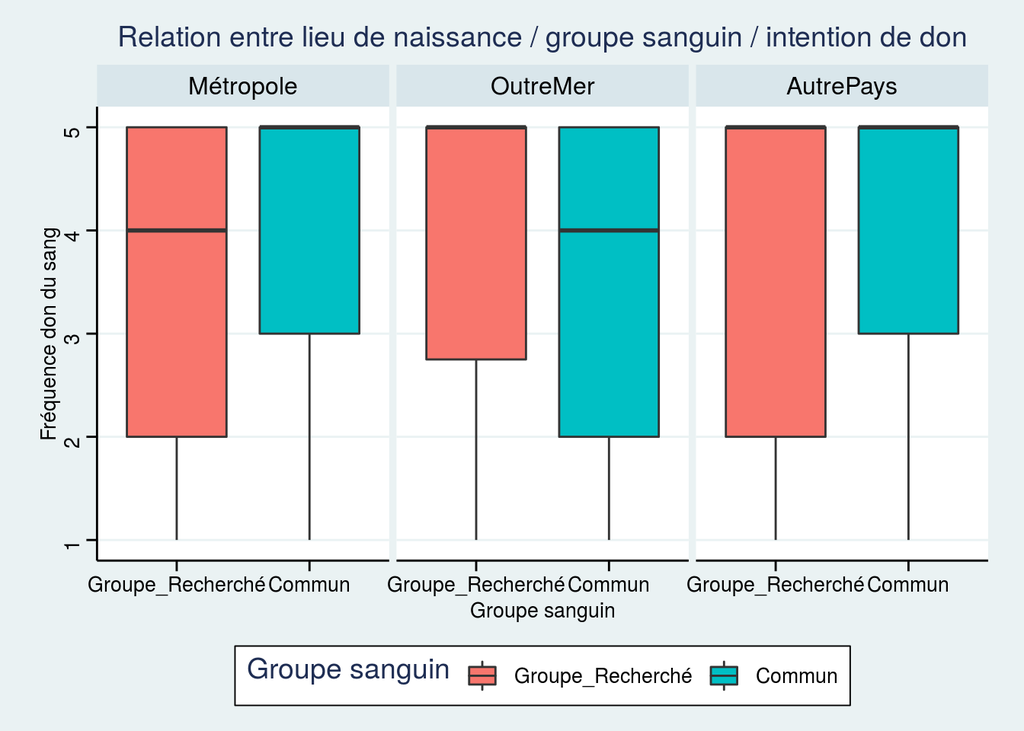

Ca graphique démontre que les individus nés en métropole et ayant un groupe sanguin recherché donnent moins souvent leur sang que les individus étant nés en Outremer ou dans un autre pays (ayant également un groupe sanguin recherché). Les individus nés en Outremer et ayant un groupe sanguin commun, donnent moins leur sang que ceux étant nés en métropole ou dans un autre pays. Cette analyse permet de mettre évidence le fait qu’il faut communiquer davantage auprès des individus nés en métropole avec un groupe sanguin recherché et auprès de ceux d’Outremer avec un groupe sanguin commun.

# **Analyses complémentaires**

Dans cette dernière section, nous allons étudier les relations qu’il peut exister entre des variables factorielles et des variables numériques sur la base des réponses de 2392 répondants (ceux ayant répondu à au moins 50% des questions). Le panel sera donc plus large sur sur la section précédente relative aux corrélations et ratios qui nécessitaient d’avoir des individus ayant répondu à l’ensemble des questions chiffrées (soit 956 individus).

## Relation entre âge et fréquence de don du sang

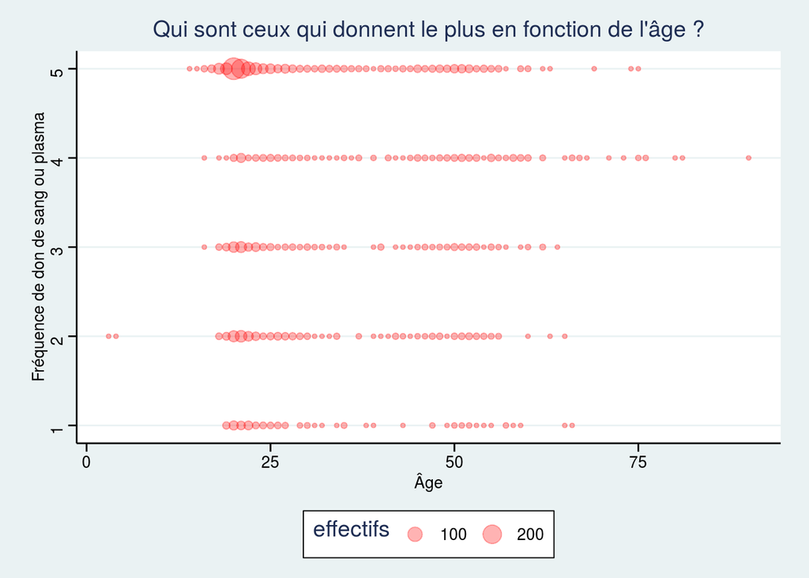

De plus, cette analyse permet de démontrer qu’il existe des “faux-répondants” à cette enquête, en effet, sur la partie gauche du graphique, nous pouvons voir deux individus ayant répondus qu’ils avaient un âge inférieur à 10 ans. Sur la partie droite, nous pouvons voir un individu ayant indiqué un âge supérieur à 90 ans qui a répondu “assez souvent” à la question de la fréquence de donner son sang, or, l’âge limite pour donner son sang est de 70 ans.

## La peur de donner son sang en fonction du sexe

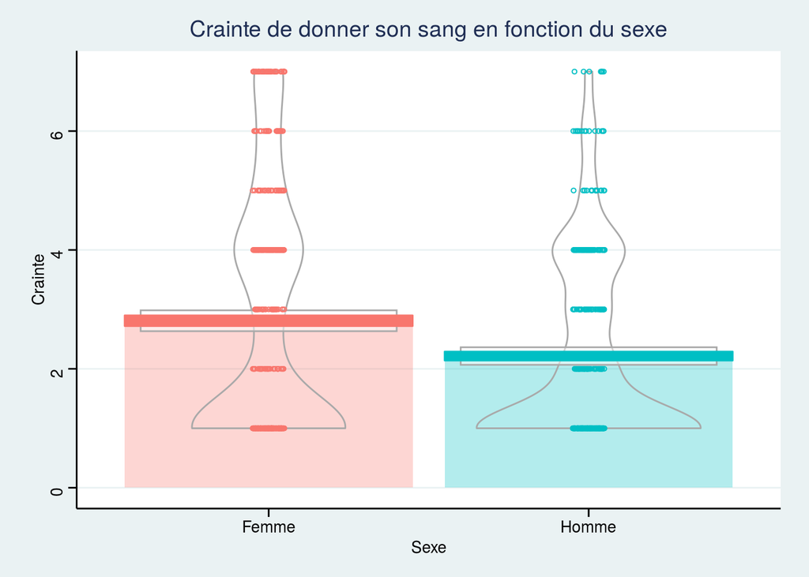

Ce graphique met en avant le fait que d’une manière générale, les femmes sont plus “craintives” à l’idée de donner leur sang que les hommes. L’écart à la moyenne reste cependant léger, toutefois, les femmes sont beaucoup plus nombreuses que les hommes à avoir répondu 5, 6 et 7 aux questions liées à la crainte. Démontrant ainsi pour les femmes que cela pouvait représenter potentiellement un frein au don du sang en raison du sentiment de peur qui accompagne l’idée d’aller donner son sang. Nous allons donc maintenant étudier dans les faits, la fréquence de don du sang en fonction du sexe, cela permettra d’établir un lien (ou non), entre le fait d’avoir peur et le fait de donner son sang.

## Fréquence de don du sang en fonction du sexe

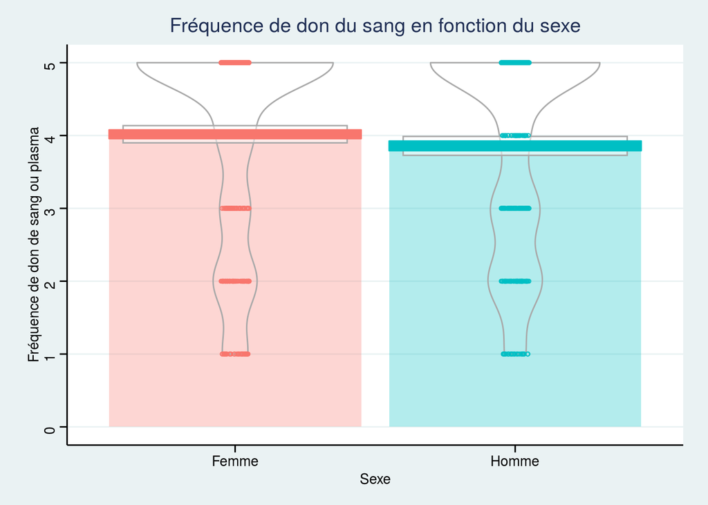

Aussi surprenant que cela puisse paraitre par rapport au graphique précédent, les femmes donnent en moyenne plus leur sang que les hommes (bien que la différence soit légère). Ainsi, nous pouvons infirmer l’existence d’un lien entre la peur de donner son sang et le passage effectif à l’action. Il faut également prendre en considération le fait que les hommes ayant répondus au questionnaire ont peut être insconsciemment dévalué leurs réponses sur les craintes, biaisant ainsi la relation entre les craintes et le passage à l’action pour donner son sang.

## Conscience de l’importance de donner son sang

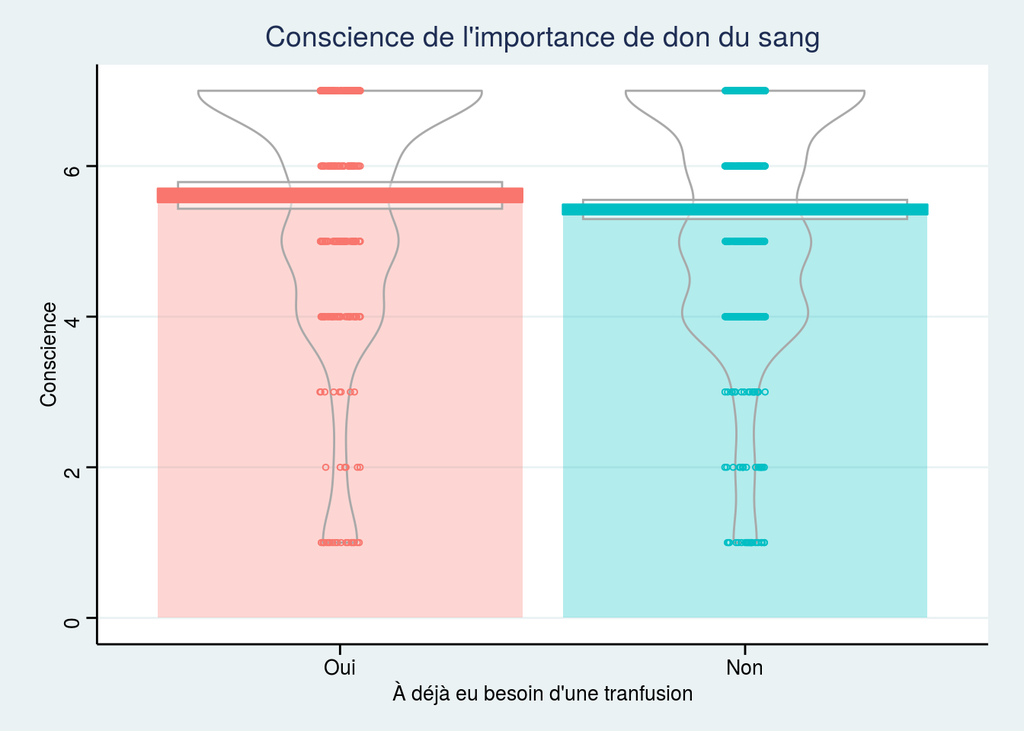

Les individus ayant déjà eu besoin (ou un de leurs proches) d’une tranfusion sanguine, sont “plus” conscients que l’absence de dons du sang peut avoir de graves conséquences. Néanmoins, l’écart est infime avec les personnes n’ayant jamais eu besoin d’une transfusion sanguine et qui semblent tous aussi bien conscients du problème.

## Confiance en l’Etablissement Français du Sang

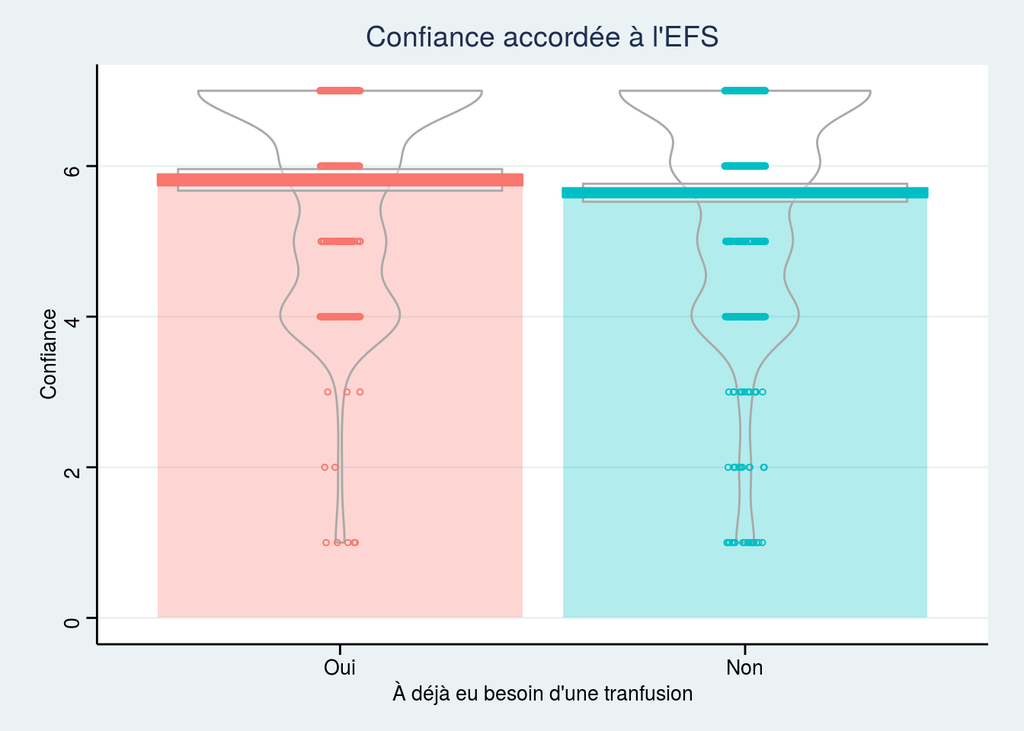

Ce dernier graphique montre la confiance accordée à l’Établissement Français du Sang en fonction des antécédents en termes de transfusion sanguine. Nous pouvons voir que la moyenne entre ceux ayant déjà reçu du sang et ceux n’en ayant pas eu besoin est quasiment la même, ce qui démontre une bonne confiance envers l’EFS. Cependant, pour les individus ayant déjà eu besoin d’une transfusion sanguine, les réponses “basses” (c’est à dire 1, 2, 3) ont été beaucoup moins nombreuses par rapport à l’autre groupe, preuve ainsi de la qualité des “services reçus” pour les individus en ayant eu besoin.